# Exploring the BRFSS data

## Setup

### Load packages

```r
library(ggplot2)
library(dplyr)
```

### Load data

```r
load("brfss2013.RData")
```

## Part 1: Data

In this observational study, the data was collected via a random sampling of the non-institutionalized adult population of each US state + US territories. Surveys were conducted by contacting randomly-selected participants by phone (land-line and mobile phone). 20% of surveys were conducted on weekdays, and 80% on weekends.

Bias: Given that the survey was conducted by a phone survey in which not every selected adult would wish to participate, the data may have been skewed by non-response bias. Furhermore, as the survey was restricted to adults residing in private households and university housing, the survey excludes those residing in institutions, communal living situations, and the homeless from the sampled population.

The sampling of exactly 1 adult from a given household controls against shared genetics and environment/lifestyle as confounding factors.

Scope of inference: As this was an observational and not experimental study, random assignment was not applied. Therefore, the data is generalizable (due to random sampling). However, causality cannot be inferred.

## Part 2: Research questions

**Research question 1:** What are the associations between gender, frequency of smoking, household income level, and level of reported general health? It would be of interest a) to determine if there are significant differences in reported general health amongst non-, occasional, and daily smokers; b) the extent to which household income level impacts general health; and c) if there are any significant gender differences in either regard.

**Research question 2:** For the segment of the sampled population that has been diagnosed with pre-diabetes or borderline diabetes, what proportion of this demographic is overweight or obese, what proportion of the population exercises regularly, and to what extent are pre-diabetes/bordernline diabetes diagnoses associated with household income level? Studies have indicated associations between obesity and the rates of diabetes. Furthermore, rates of early-onset diabetes have been correlated with socioeconomic status in the US, due in part to a lack of means to afford nutritious food amongst low-income populations, and to poor lifestyle habits (e.g., lack of regular physical exercise). Changes in activity levels and dietary patterns could reduce the risk of diabetes.

**Research question 3:** What is the relationship between obesity and state of residence, race, income level, and education level? Obesity rates vary according to US state/terrority. In the states with highest rates of obesity, it would be of interest to closely examine the breakdown of obesity rate by race (restricted in this case to White and Black/African American) and income level, to determine the extent to which either of these variables are indeed associated with obesity. On a more general level, it would be instructive to examine the distribution of education levels across the different body mass index categories, to determine if there is a possible correlation between limited education and the unhealthy lifestyle habits that lead to obesity.

## Part 3: Exploratory data analysis

**Research question 1:**

First, a data frame is constructed in which “NA” cases for smoking frequency, general health, and household income variables:

```r
brfss2013_smoke_income <- brfss2013 %>%
  filter(!is.na(smokday2) & !is.na(genhlth) & !is.na(income2))
```

Next, general health levels are plotted for males vs. females with respect to smoking frequency (every day/some days/not at all):

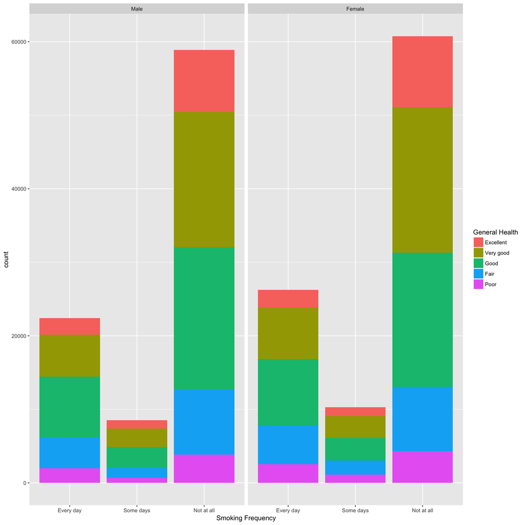

```r
ggplot(data = brfss2013_smoke_income, aes(x = smokday2,  fill = genhlth)) + geom_bar() + facet_wrap(~ sex, ncol = 2)  + xlab("Smoking Frequency") + labs(fill = "General Health")
```

Finally, general health levels are plotted for males vs. females with respect to household income level:

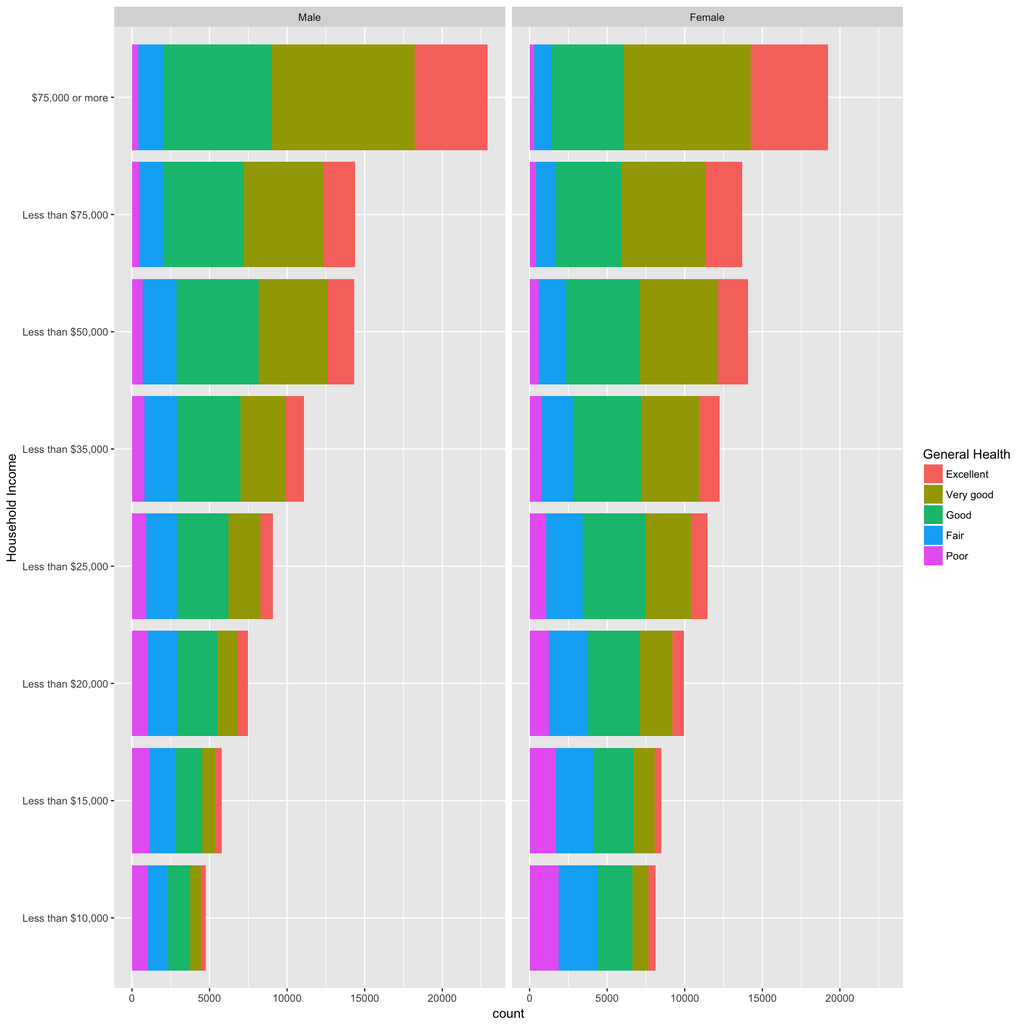

```r
ggplot(data = brfss2013_smoke_income, aes(x = income2,  fill = genhlth)) + geom_bar() + facet_wrap(~ sex, ncol = 2) + coord_flip()  + xlab("Household Income") + labs(fill = "General Health")
```

Conclusion:

**Research question 2:**

For the sake of convenience of calculations for research questions 2 + 3, the income level variable is converted from factor to numeric values (1-8):

```r
brfss2013 <- transform(brfss2013, income2 = as.numeric(income2))

 is.numeric(brfss2013$income2)
```

```
## [1] TRUE
```

A dataframe containing values for the relevant relevant variables (prediab1, X_bmi5cat, income2, and exerany2) is constructed:

```r
diabetes_data <- brfss2013 %>%
  filter(prediab1 == "Yes" & !is.na(X_bmi5cat) & !is.na(income2) & !is.na(exerany2)) %>%
  select(prediab1, X_bmi5cat,income2, exerany2)
```

In the following dataframe, the tallies of the total population exercising and non-exercising, obese, overweight, and normal weight, lower income, obese + lower income, and overweight + lower income, and normal weight + lower income segments are represented:

```r
diabetes_summary <- diabetes_data %>%
  select(prediab1, exerany2,X_bmi5cat, income2) %>%
  summarise(total_population = n(), active = sum(exerany2 == "Yes"), inactive = sum(exerany2 == "No"), obese = sum(X_bmi5cat == "Obese"), overweight = sum(X_bmi5cat == "Overweight"), normalweight = sum(X_bmi5cat == "Normal weight"),  lower_income = sum(income2<=4), obese_lower_income = sum(X_bmi5cat == "Obese" & income2 <=4), overweight_lower_income = sum(X_bmi5cat == "Overweight" & income2 <=4), normalweight_lower_income = sum(X_bmi5cat == "Normal weight" & income2 <=4))
```

Based upon these totals, proportions of active vs. inactive members of the population (out of the total population), obese, overweight, and normal weight segments (out of the total population), lower income segments (out of the total population), and obese, overweight, and normal weight lower income segments (out of the total obese, overweight, and normal weight segments, respectively) are calculated:

```r
diabetes_summary <- diabetes_summary %>%
  mutate(prop_active = (active/total_population) * 100, prop_inactive =  (inactive/total_population) * 100, prop_obese = (obese/total_population) * 100, prop_overweight = (overweight/total_population) * 100, prop_normalweight = (normalweight/total_population) * 100, prop_lower_income = (lower_income/total_population) * 100,  prop_obese_lower_income = (obese_lower_income/obese) * 100, prop_overweight_lower_income = (overweight_lower_income/overweight) * 100, prop_normalweight_lower_income = (normalweight_lower_income/normalweight)* 100)
```

As is indicated in this dataframe, the number of obese and overweight members of this population is high (ca. 46% and 35% respectively), for a total of ca. 81%. The population of lower-income segments is ca. 36%. The proportions of obese, overweight, and normal weight segments of the population that are lower-income are ca. 36%, 33%, and 38%, respectively. As such,it does not appear that there is an association between either pre-diabetes/borderline diabetes diagnoses, or between BMI category and income level within this sample.

In the following bar graph, the population sample is segmented into BMI categories:

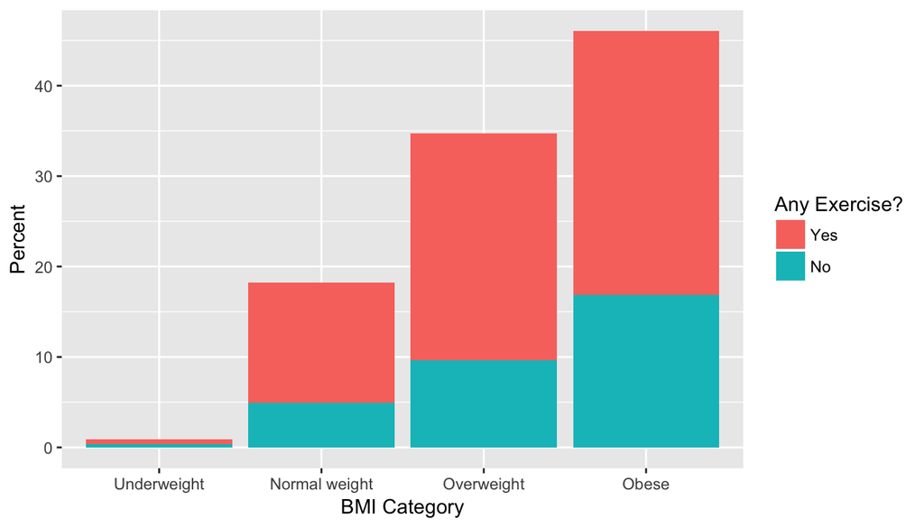

```r
ggplot(diabetes_data, aes(x = X_bmi5cat, fill = exerany2)) + geom_bar(aes(y = 100 *(..count../sum(..count..)))) + xlab("BMI Category") + ylab("Percent")+ labs(fill = "Any Exercise?")
```

As is evident above, a significant percentage of this population is overweight or obese.

Here is the income level breakdown for each BMI category:

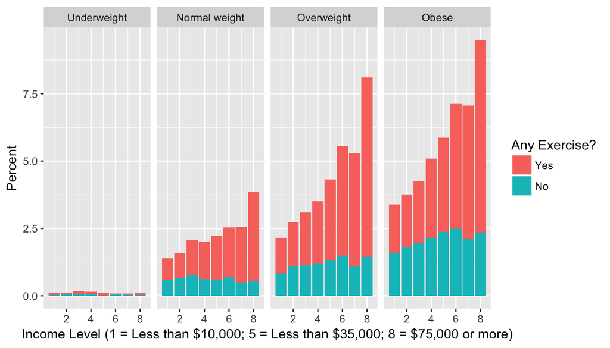

```r
ggplot(diabetes_data, aes(x = income2, fill = exerany2)) + geom_bar(aes(y = 100 *(..count../sum(..count..)))) + xlab("Income Level (1 = Less than $10,000; 5 = Less than $35,000; 8 = $75,000 or more)") + ylab("Percent")+ labs(fill = "Any Exercise?")+ facet_wrap( ~ X_bmi5cat, ncol = 4)
```

Conclusion:

Based upon the above data analyses and plots, there does appear to be a strong association between pre-diabetes/borderline diabetes diagnoses and BMI category. However, there are no clear correlations between pre-diabetes/borderline diabetes diagnoses and either income level or activity level. That said: the percentage of the total surveyed population that has reported to have been diagnosed with pre-diabetes/borderline diabetes is relatively small, and the “yes/no” “exerany2” categorical variable is lacking in precision and reliability.

**Research question 3:**

First, a data frame called “state_obesity” is constructed, in which the number of obesity cases for each state, the total population of respondents for each state (minus those whose BMI category = “NA”), the respective White vs. Black/African American totals and obese White vs. Black/African American totals, the total number of lower income respondents, and the total number of obese lower income respondents are tallied:

```r
 state_obesity <- brfss2013 %>%
 group_by(X_state) %>%
 filter(!is.na(X_bmi5cat) & !is.na(income2) & !is.na(X_prace1)) %>%
 summarise(total_obese = sum(X_bmi5cat == "Obese"), total_population = n(), total_white = sum(X_prace1 == "White"), total_black = sum(X_prace1 == "Black or African American"),total_white_obese = sum(X_prace1 == "White" & X_bmi5cat == "Obese"),  total_black_obese = sum(X_prace1 == "Black or African American" & X_bmi5cat =="Obese"),  total_low_income = sum(income2 <= 4), obese_low_income = sum(X_bmi5cat == "Obese" & income2 <=4))
```

For the sake of readability, the variable “Xstate” is renamed “state” in the state_obesity dataframe:

```r
colnames(state_obesity)[1] <- "state"
```

To this data frame, we add the variable “prop_obese,” i.e., the proportion obesity cases divided by the total population for each state. Observations (states) in the data frame are then rearranged in descending order of obesity percentage:

```r
state_obesity <- state_obesity %>%
 mutate(prop_obese = (total_obese/total_population) * 100) %>%
 arrange(desc(prop_obese))
```

Here is a histogram indicating obesity levels:

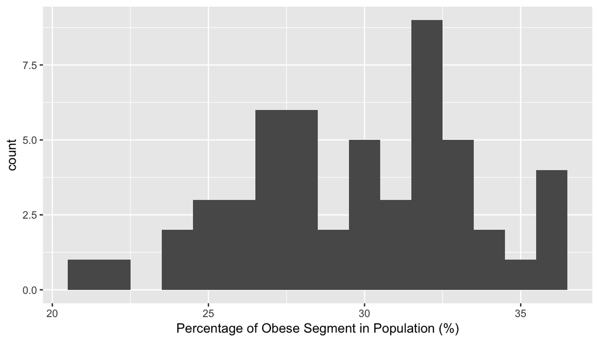

```r
 ggplot(data = state_obesity, aes(x = prop_obese)) + geom_histogram(binwidth = 1) + xlab("Percentage of Obese Segment in Population (%)")
```

```r
state_obesity%>%
  summarise(med = median(prop_obese), mean = mean(prop_obese))
```

```
## # A tibble: 1 x 2
##     med  mean
##   <dbl> <dbl>
## 1  29.9  29.7
```

The mean and median obesity rates are 29.7% and 29.9%, respectively, suggesting a symmetric distribution across states.

Thereafter, the proportions of obese Whites vs. Blacks/African Americans to total Whites vs. Blacks/African Americans is calculated:

```r
state_obesity <- state_obesity %>%
  mutate(prop_white_obese = (total_white_obese/total_white) * 100, prop_black_obese = (total_black_obese/total_black) * 100)
```

Now, the proportion of lower-income respondents out of the total respondent population, and the number of obese lower income respondents out of the obese population are calculated:

```r
state_obesity <- state_obesity %>%
  mutate(prop_low_income = (total_low_income/total_population) * 100, prop_obese_low_income = (obese_low_income/total_obese) * 100)
```

```r
state_obesity <- state_obesity %>%
  mutate(diff_obese_total_low_income = prop_obese_low_income - prop_low_income)
```

Let’s more closely investigate the states that fall within the 80th percentile or higher for obesity:

```r
 top_twentieth_perc_obesity_states <- state_obesity %>%
  filter (prop_obese >= quantile(state_obesity$prop_obese, 0.8))
```

That leaves 11 states in the top 20%. Using a segmented bar graph, the total populations and obesity proportions of each of these 11 states are plotted:

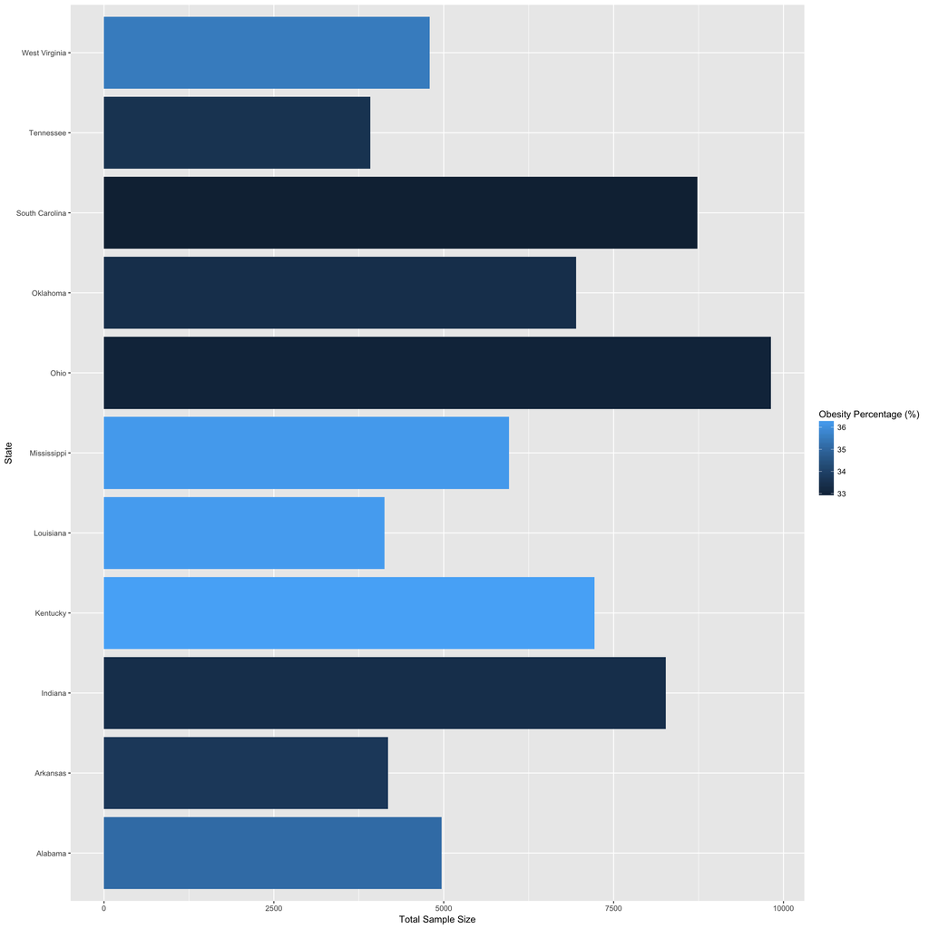

```r
ggplot(data = top_twentieth_perc_obesity_states, aes(x = state, y = total_population, fill = prop_obese)) + geom_col() + xlab("State") + ylab("Total Sample Size")  + labs(fill = "Obesity Percentage (%)") + coord_flip()
```

Now, let’s examine differences in racial obesity distribution for these 11 states. Here are graphs of obesity rates for each state amongst White and Black/African American populations:

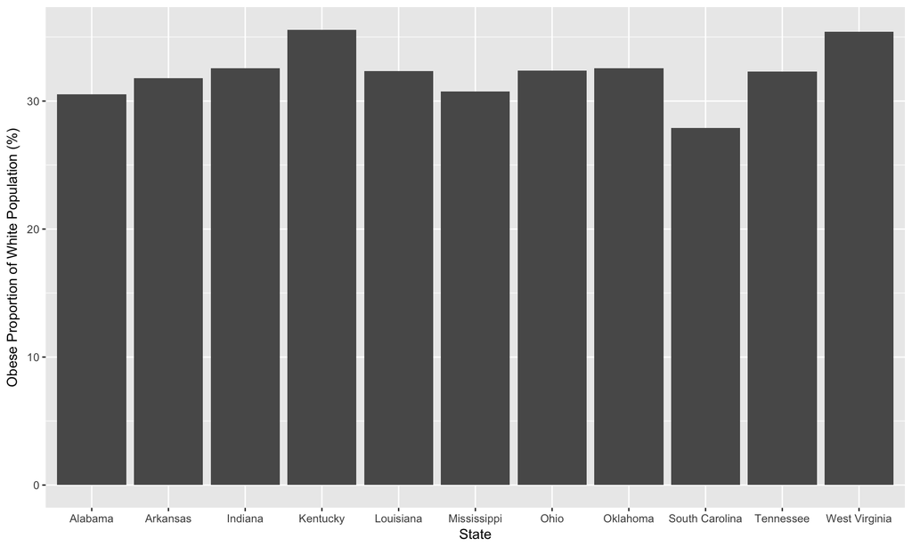

```r
ggplot(data = top_twentieth_perc_obesity_states, aes(x = state, y = prop_white_obese)) + geom_col() + xlab("State") + ylab("Obese Proportion of White Population (%)")
```

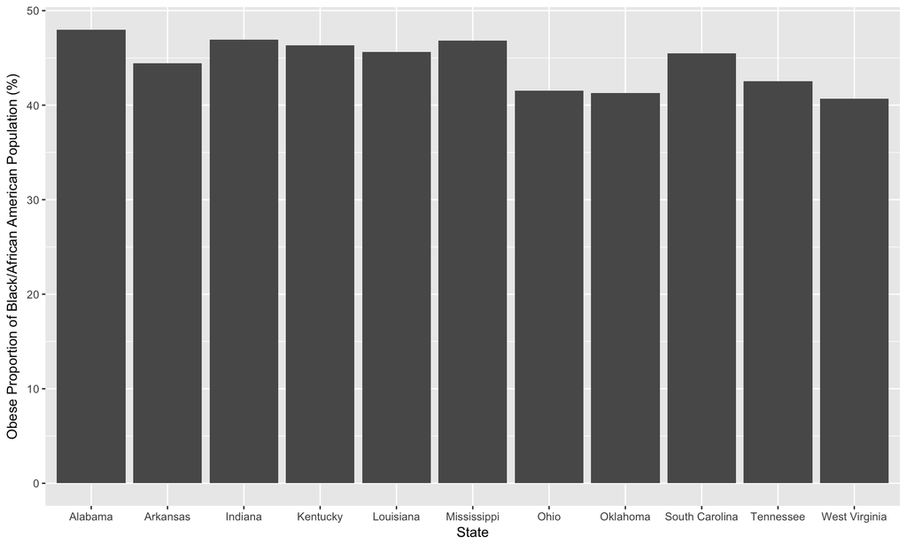

```r
ggplot(data = top_twentieth_perc_obesity_states, aes(x = state, y = prop_black_obese)) + geom_col() + xlab("State") + ylab("Obese Proportion of Black/African American Population (%)")
```

In comparing the 2 graphs, it is clear that a greater percentage of the Black/African American population suffers from obesity than is the case for the White population for each state. This trend extends to most of the 53 surveyed states/territories.

To put this in a broader BMI and racial demographic context:

```r
brfss2013 <- brfss2013 %>%
  filter(!is.na(X_bmi5cat) & !is.na(X_prace1))
```

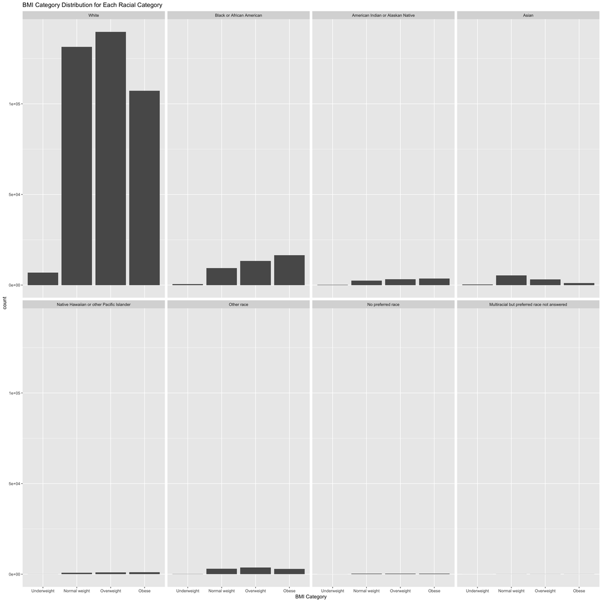

```r
ggplot(data = brfss2013, aes(x = X_bmi5cat)) + geom_bar(position = "dodge") + facet_wrap(~ X_prace1, ncol = 4) + ggtitle("BMI Category Distribution for Each Racial Category") + xlab("BMI Category")
```

There also exist consistent differences between the proportion of lower-income members of the obese population to the total obese population, and the proportion of total lower-income population to the total population.

Below if a graph of percentage differences between proportions of the lower-income obese demographic to the total obese population and the total lower-income demographic to the total population of each of the top 11 states:

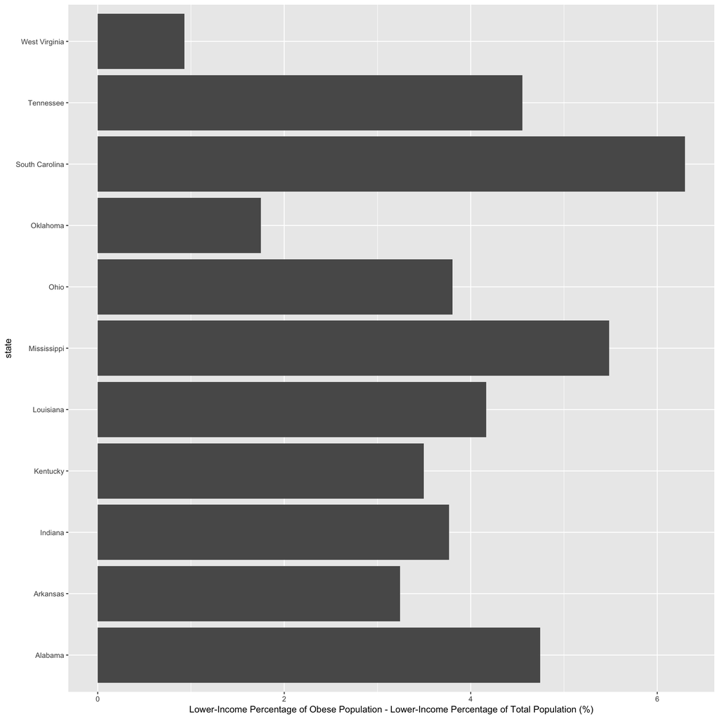

```r
ggplot(data = top_twentieth_perc_obesity_states, aes(x = state, y = diff_obese_total_low_income)) + geom_col() + ylab("Lower-Income Percentage of Obese Population - Lower-Income Percentage of Total Population (%)") + coord_flip()
```

With respect to education level: here is a bar graph of four different levels of education as a function of BMI category. “N/A” responses for the BMI category and education level categorical variables have been filtered out:

```r
brfss2013<- brfss2013 %>%
  filter(!is.na(X_bmi5cat) & !is.na(X_educag))
```

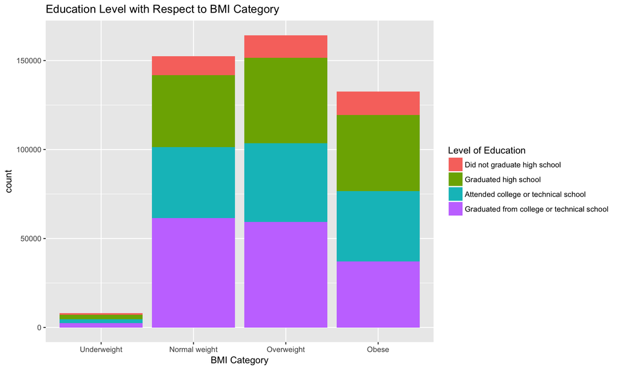

```r
ggplot(data = brfss2013, aes(x = X_bmi5cat, fill = X_educag)) + geom_bar() + ggtitle("Education Level with Respect to BMI Category") + xlab("BMI Category") + labs(fill = "Level of Education")
```

There are too few responses in the “Underweight” category to factor it into comparisons with other BMI categories, but based upon the differences in distributions between the “Normal”" and “Overweight”" categories on the one hand,and the “Obese” category on the other, it is evident that a smaller percentage of the “Obese” category graduated from a college or technical school. As such, there appears to be a negative association between obesity and education level.

Conclusion:

Obesity rates vary across the 53 surveyed states/territories, within a range of ca. 21-36%.

The association between White vs. Black/African American racial category and obesity appears to be strong, applying to 49 of the 53 states/territories surveyed.

Percentages of the obese population that are lower-income are slightly but consistently higher than the percentage of lower-income respondents to all respondents, suggesting a negative association between income level and obesity.

Furthermore, it would seem that there are proportionately (and significantly) fewer members of the “Obese” category with higher education degrees.

Additional data with respect to family medical history would have to be gathered in order to more systematically assess genetic and environmental factors leading to obesity conditions.